# HUDM 6026 HW 13

Frank Li & Getong Zhong

2023-04-30

# 1.

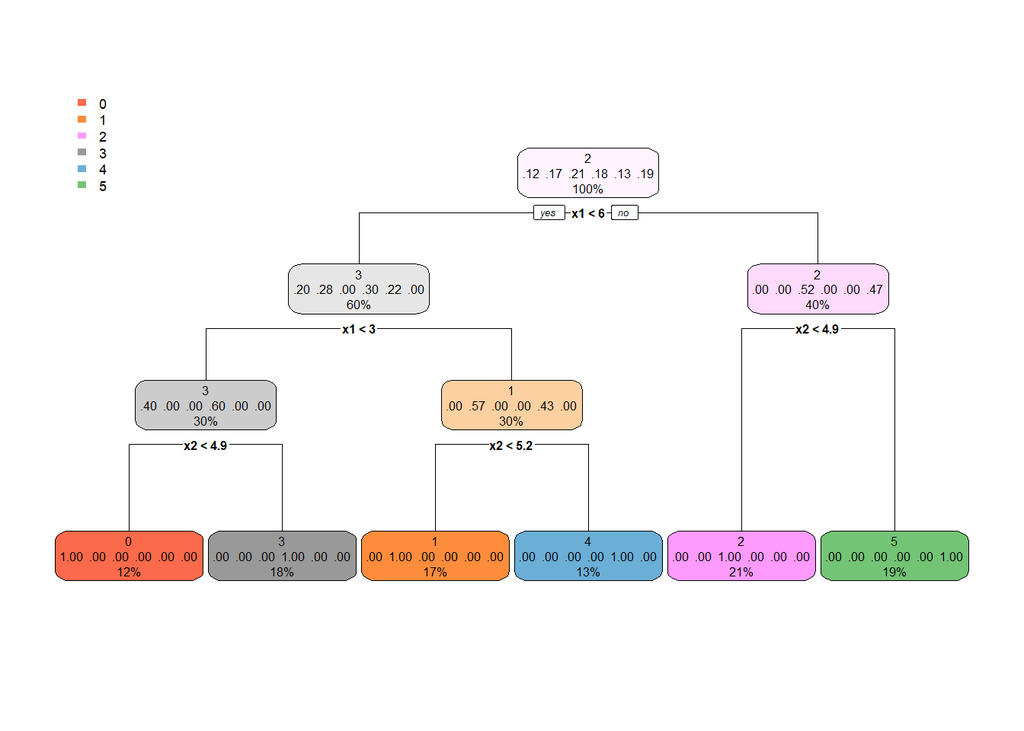

```r
library(rpart)
library(rpart.plot)
set.seed(123)
n <- 100
x1 <- runif(n, 0, 10)
x2 <- runif(n, 0, 10)
assign_region <- function(x1, x2) {
  if (x1 < 3 & x2 < 5) return(0)
  if (x1 >= 3 & x1 < 6 & x2 < 5) return(1)
  if (x1 >= 6 & x2 < 5) return(2)
  if (x1 < 3 & x2 >= 5) return(3)
  if (x1 >= 3 & x1 < 6 & x2 >= 5) return(4)
  if (x1 >= 6 & x2 >= 5) return(5)
}
y <- mapply(assign_region, x1, x2)
df <- data.frame(x1, x2, y)
tree <- rpart(y ~ x1 + x2, data = df, method = "class")

rpart.plot(tree)
```

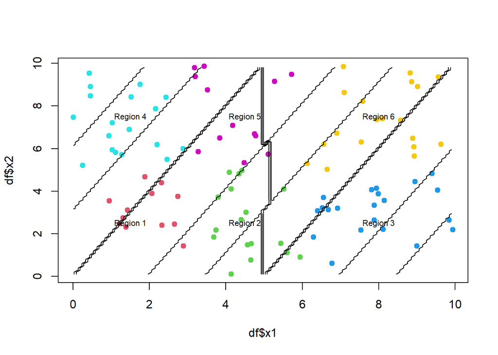

```r
grid_size <- 0.1
grid_x1 <- seq(min(df$x1), max(df$x1), by = grid_size)
grid_x2 <- seq(min(df$x2), max(df$x2), by = grid_size)
grid_df <- expand.grid(x1 = grid_x1, x2 = grid_x2)

# Predict the grid points using the decision tree
grid_df$y_pred <- predict(tree, grid_df, type = "class")
# Create a matrix of the predicted values for contour plot
pred_matrix <- matrix(grid_df$y_pred, nrow = length(grid_x2), ncol = length(grid_x1))

# Add the contour plot (decision boundary)
plot(df$x1, df$x2, col = y + 2, pch = 19)

# Add the contour plot (decision boundaries)
contour(grid_x1, grid_x2, t(pred_matrix), levels = c(0.5, 1.5, 2.5, 3.5, 4.5), drawlabels = FALSE, add = TRUE)
region_labels <- c("Region 1", "Region 2", "Region 3", "Region 4", "Region 5", "Region 6")
region_centers <- data.frame(x1 = c(1.5, 4.5, 8, 1.5, 4.5, 8), x2 = c(2.5, 2.5, 2.5, 7.5, 7.5, 7.5))
text(region_centers$x1, region_centers$x2, labels = region_labels, cex = 0.7, col = "black")
```

# 5.

Majority vote approach:

There are 6 estimates of P > 0.5 so the final classification is red.

Classify based on the average probability:

```r
mean(c(0.1, 0.15, 0.2, 0.2, 0.55, 0.6, 0.6, 0.65, 0.7, 0.75))
```

```
## [1] 0.45
```

The average probability is 0.45 so the final classification is green.

# 6.

First the algorithm starts with the whole data set as the root node and repeatedly select the best split point to minimize the residuals. And then, the data partitioned based on the selected split points, and repeat this process for each child node until the end of the iteration, usually known as when the maximum depth are met. When we met the end of the iteration, terminal nodes are created, meanwhile, the mean of the target variable within the node is assigned to each child node.

# 8.

## (a)

```r
library (tree)
library (ISLR2)
attach (Carseats)
set.seed (123)
train <- sample (1: nrow (Carseats), nrow(Carseats)/2)
Carseats.train <- Carseats[train , ]
Carseats.test <- Carseats[-train , ]
```

## (b)

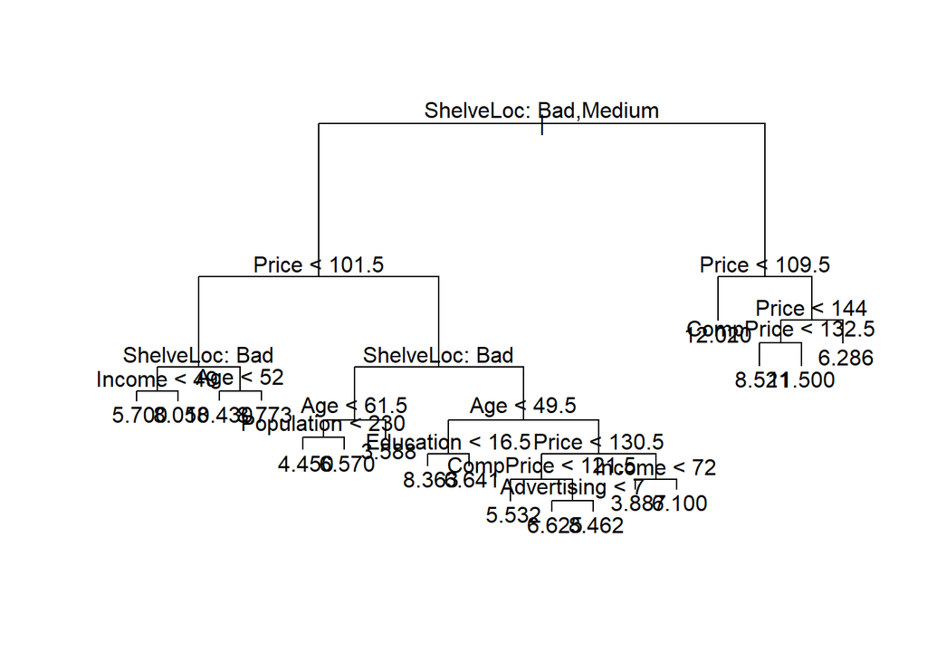

```r
tree.carseats <- tree (Sales ~., data = Carseats.train)
plot(tree.carseats)
text(tree.carseats, pretty = 0)
```

```r
tree.pred <- predict (tree.carseats , Carseats.test)
mean((tree.pred - Carseats.test$Sales)^2)
```

```
## [1] 4.395357
```

ShelveLoc and price are two variables that can best predict Sales since they appear on the top of the regression tree. The test MSE is 4.395357.

## (c)

```r
cv.carseats <- cv.tree(tree.carseats , FUN = prune.tree)
names (cv.carseats)
```

```
## [1] "size"   "dev"    "k"      "method"
```

```r
cv.carseats
```

```
## $size
##  [1] 18 17 16 15 14 13 12 11 10  9  8  7  6  5  4  3  2  1
##
## $dev
##  [1] 1031.879 1018.558 1018.558 1009.770 1034.843 1053.537 1057.967 1051.468
##  [9] 1137.244 1120.642 1158.929 1156.106 1161.057 1216.548 1223.958 1207.253
## [17] 1242.554 1473.414
##
## $k
##  [1]      -Inf  16.93456  17.10094  18.36513  19.36805  21.17568  22.24728
##  [8]  32.41359  39.73324  41.38229  42.06332  44.28093  46.53155  63.12600
## [15]  80.51350  96.97503 166.93502 281.96185
##
## $method
## [1] "deviance"
##
## attr(,"class")
## [1] "prune"         "tree.sequence"
```

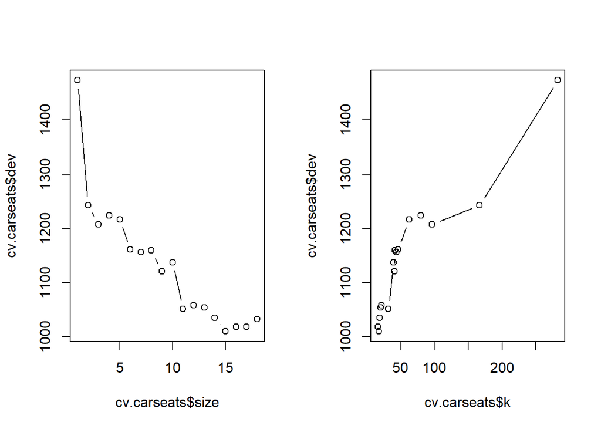

```r
par (mfrow = c(1, 2))
plot (cv.carseats$size , cv.carseats$dev, type = "b")
plot (cv.carseats$k, cv.carseats$dev, type = "b")
```

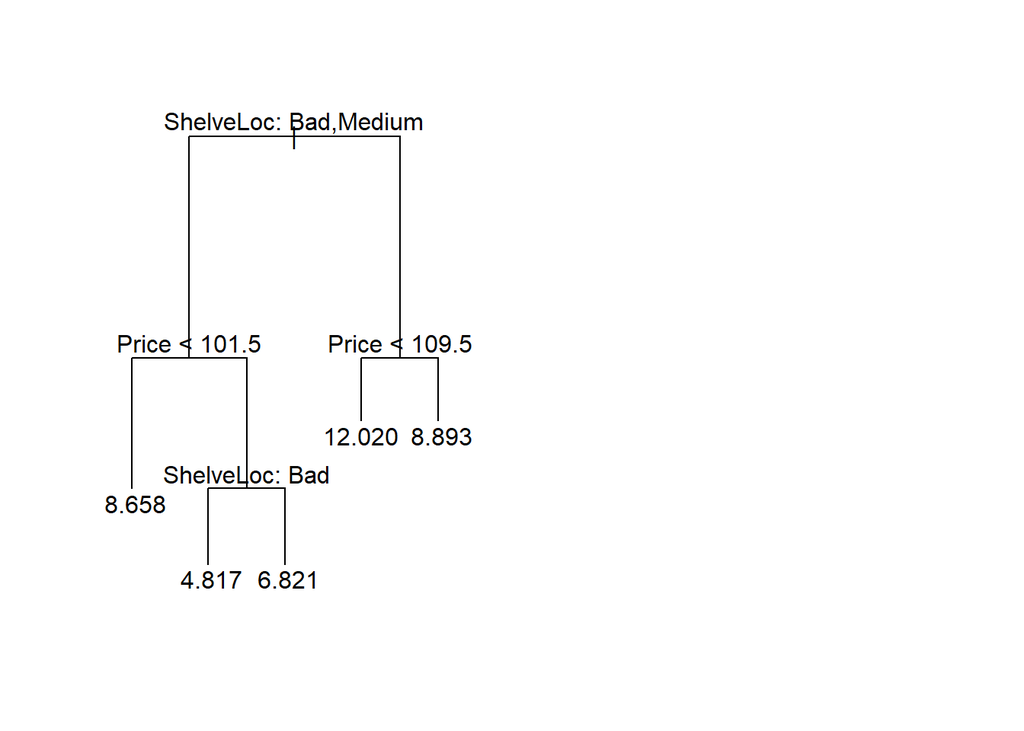

```r
prune.carseats <- prune.tree (tree.carseats , best = 5)
plot (prune.carseats)
text (prune.carseats , pretty = 0)
```

```r
tree.pred <- predict (prune.carseats , Carseats.test)
mean((Carseats.test$Sales - tree.pred)^2)
```

```
## [1] 4.798268
```

Pruning the tree DOES NOT improve the MSE, i.e. it goes from 4.395357 to 4.798268.